# Analysis of Thomas Poulton’s Descriptions

Bodo Winter

3/5/2020

## Preprocessing

Load data and packages:

```r
# Packages:

library(tidyverse)
library(tidytext)
library(lavaan)
library(effsize)
library(corrplot)
library(gridExtra)

# Data:

scents <- read_csv('../data/by_scent_cleaned.csv')
war <- read_csv('../data/warriner_2013_cleaned.csv')
lyn <- read_csv('../data/lynott_norms.csv')
```

## Confirmatory factor analysis of codability:

Z-score variables that enter the CFA:

```r
scents <- mutate(scents,
                 Length_z = scale(Length),
                 TextEntropy_z = scale(TextEntropy),
                 Jaccard_z = scale(jaccard))
```

Create formula for latent variable ‘codability’ that is indicated by the three measures (length, text entropy, and inter-speaker agreement measured by jaccard similarity).

```r
CFA_formula <- 'Codability =~ Length_z + TextEntropy_z + Jaccard_z'
```

Fit this CFA:

```r
CFA_fit <- cfa(CFA_formula, data = scents)
CFA_fit
```

```
## lavaan 0.6-5 ended normally after 25 iterations
##
##   Estimator                                         ML
##   Optimization method                           NLMINB
##   Number of free parameters                          6
##
##   Number of observations                            42
##
## Model Test User Model:
##
##   Test statistic                                 0.000
##   Degrees of freedom                                 0
```

Summarize it:

```r
summary(CFA_fit, fit.measures = TRUE, standardized = TRUE)
```

```
## lavaan 0.6-5 ended normally after 25 iterations
##
##   Estimator                                         ML
##   Optimization method                           NLMINB
##   Number of free parameters                          6
##
##   Number of observations                            42
##
## Model Test User Model:
##
##   Test statistic                                 0.000
##   Degrees of freedom                                 0
##
## Model Test Baseline Model:
##
##   Test statistic                                71.181
##   Degrees of freedom                                 3
##   P-value                                        0.000
##
## User Model versus Baseline Model:
##
##   Comparative Fit Index (CFI)                    1.000
##   Tucker-Lewis Index (TLI)                       1.000
##
## Loglikelihood and Information Criteria:
##
##   Loglikelihood user model (H0)               -141.678
##   Loglikelihood unrestricted model (H1)       -141.678
##
##   Akaike (AIC)                                 295.355
##   Bayesian (BIC)                               305.781
##   Sample-size adjusted Bayesian (BIC)          286.992
##
## Root Mean Square Error of Approximation:
##
##   RMSEA                                          0.000
##   90 Percent confidence interval - lower         0.000
##   90 Percent confidence interval - upper         0.000
##   P-value RMSEA <= 0.05                             NA
##
```

[output cut: 8 more lines]

```
##   Standard errors                             Standard
##
## Latent Variables:
##                    Estimate  Std.Err  z-value  P(>|z|)   Std.lv  Std.all
##   Codability =~
##     Length_z          1.000                               0.584    0.591
##     TextEntropy_z     1.946    0.555    3.505    0.000    1.136    1.150
##     Jaccard_z        -1.166    0.270   -4.321    0.000   -0.681   -0.689
##
## Variances:
##                    Estimate  Std.Err  z-value  P(>|z|)   Std.lv  Std.all
##    .Length_z          0.636    0.151    4.196    0.000    0.636    0.651
##    .TextEntropy_z    -0.314    0.241   -1.306    0.192   -0.314   -0.322
##    .Jaccard_z         0.513    0.139    3.684    0.000    0.513    0.526
##     Codability        0.341    0.173    1.972    0.049    1.000    1.000
```

## Structural equation model with haptic:

Haptic SEM formula, regressing haptic ratings per description onto the latent factor codability:

```r
haptic_SEM_formula <- '
  # measurement model:
  Codability =~ Length_z + TextEntropy_z + Jaccard_z

  # regression:
  Haptic ~ Codability'
```

Fit SEM:

```r
haptic_SEM_fit <- cfa(haptic_SEM_formula, data = scents)
```

Summarize:

```r
summary(haptic_SEM_fit)
```

```
## lavaan 0.6-5 ended normally after 22 iterations
##
##   Estimator                                         ML
##   Optimization method                           NLMINB
##   Number of free parameters                          8
##
##   Number of observations                            42
##
## Model Test User Model:
##
##   Test statistic                                 8.461
##   Degrees of freedom                                 2
##   P-value (Chi-square)                           0.015
##
## Parameter Estimates:
##
##   Information                                 Expected
##   Information saturated (h1) model          Structured
##   Standard errors                             Standard
##
## Latent Variables:
##                    Estimate  Std.Err  z-value  P(>|z|)
##   Codability =~
##     Length_z          1.000
##     TextEntropy_z     1.581    0.332    4.769    0.000
##     Jaccard_z        -1.161    0.244   -4.761    0.000
##
## Regressions:
##                    Estimate  Std.Err  z-value  P(>|z|)
##   Haptic ~
##     Codability        0.370    0.150    2.458    0.014
##
## Variances:
##                    Estimate  Std.Err  z-value  P(>|z|)
##    .Length_z          0.553    0.129    4.291    0.000
##    .TextEntropy_z    -0.083    0.123   -0.674    0.500
##    .Jaccard_z         0.405    0.109    3.706    0.000
##    .Haptic            0.367    0.080    4.618    0.000
##     Codability        0.424    0.181    2.336    0.019
```

R-squared:

```r
inspect(haptic_SEM_fit, 'r2')
```

```
##      Length_z TextEntropy_z     Jaccard_z        Haptic
##         0.434            NA         0.585         0.136
```

## Structural equation model with source-based:

Scale source:

```r
scents <- mutate(scents,
                 Source_z = Source - mean(Source),
                 Source_z = Source_z / sd(Source_z))
```

```r
source_SEM_formula <- '
  # measurement model:
  Codability =~ Length_z + TextEntropy_z + Jaccard_z

  # regression:
  Source_z ~ Codability'
```

Fit SEM:

```r
source_SEM_fit <- cfa(source_SEM_formula, data = scents)
```

```
## Warning in lav_object_post_check(object): lavaan WARNING: some estimated ov
## variances are negative
```

Summarize:

```r
summary(source_SEM_fit)
```

```
## lavaan 0.6-5 ended normally after 23 iterations
##
##   Estimator                                         ML
##   Optimization method                           NLMINB
##   Number of free parameters                          8
##
##   Number of observations                            42
##
## Model Test User Model:
##
##   Test statistic                                 1.524
##   Degrees of freedom                                 2
##   P-value (Chi-square)                           0.467
##
## Parameter Estimates:
##
##   Information                                 Expected
##   Information saturated (h1) model          Structured
##   Standard errors                             Standard
##
## Latent Variables:
##                    Estimate  Std.Err  z-value  P(>|z|)
##   Codability =~
##     Length_z          1.000
##     TextEntropy_z     1.636    0.309    5.291    0.000
##     Jaccard_z        -1.153    0.244   -4.727    0.000
##
## Regressions:
##                    Estimate  Std.Err  z-value  P(>|z|)
##   Source_z ~
##     Codability       -1.026    0.239   -4.301    0.000
##
## Variances:
##                    Estimate  Std.Err  z-value  P(>|z|)
##    .Length_z          0.564    0.122    4.637    0.000
##    .TextEntropy_z    -0.126    0.086   -1.468    0.142
##    .Jaccard_z         0.429    0.098    4.364    0.000
##    .Source_z          0.542    0.118    4.608    0.000
##     Codability        0.412    0.173    2.383    0.017
```

Need to investigate warning messages.

Check AICs of the CFA versus the two SEMs:

```r
AIC(CFA_fit)
```

```
## [1] 295.3553
```

```r
AIC(source_SEM_fit)
```

```
## [1] 387.6107
```

```r
AIC(haptic_SEM_fit)
```

```
## [1] 377.5073
```

Is this actually interpretable? (not sure what counts as the metric in an SEM context)

Double check:

```r
CFA_scores <- predict(CFA_fit)[, 1]
summary(lm(scents$Source ~ CFA_scores))
```

```
##
## Call:
## lm(formula = scents$Source ~ CFA_scores)
##
## Residuals:
##      Min       1Q   Median       3Q      Max
## -0.22599 -0.11015  0.01485  0.06578  0.22792
##
## Coefficients:
##             Estimate Std. Error t value Pr(>|t|)
## (Intercept)  0.66193    0.01757  37.683  < 2e-16 ***
## CFA_scores  -0.14031    0.02379  -5.897  6.6e-07 ***
## ---
## Signif. codes:  0 '***' 0.001 '**' 0.01 '*' 0.05 '.' 0.1 ' ' 1
##
## Residual standard error: 0.1138 on 40 degrees of freedom
## Multiple R-squared:  0.465,  Adjusted R-squared:  0.4517
## F-statistic: 34.77 on 1 and 40 DF,  p-value: 6.601e-07
```

```r
summary(lm(scents$Haptic ~ CFA_scores))
```

```
##
## Call:
## lm(formula = scents$Haptic ~ CFA_scores)
##
## Residuals:
##      Min       1Q   Median       3Q      Max
## -1.14055 -0.54554  0.05976  0.42924  1.57320
##
## Coefficients:
##             Estimate Std. Error t value Pr(>|t|)
## (Intercept)  1.94702    0.09939   19.59   <2e-16 ***
## CFA_scores   0.23428    0.13463    1.74   0.0895 .
## ---
## Signif. codes:  0 '***' 0.001 '**' 0.01 '*' 0.05 '.' 0.1 ' ' 1
##
## Residual standard error: 0.6441 on 40 degrees of freedom
## Multiple R-squared:  0.07038,    Adjusted R-squared:  0.04714
## F-statistic: 3.028 on 1 and 40 DF,  p-value: 0.08952
```

## Analysis of efficient codability measures:

First, extract those:

```r
codability <- select(scents, jaccard, TextEntropy, Length)
```

Correlate these with each other:

```r
corrs <- cor(codability)
```

What are the correlations?

```r
round(corrs, 2)
```

```
##             jaccard TextEntropy Length
## jaccard        1.00       -0.79  -0.41
## TextEntropy   -0.79        1.00   0.68
## Length        -0.41        0.68   1.00
```

Extract a conjoined measure. First, z-score:

```r
codability_z <- apply(codability, 2, FUN = scale)
```

Perform a PCA on this:

```r
cod_PCA <- prcomp(codability_z, center = TRUE, scale = TRUE)
```

Check variance explained:

```r
summary(cod_PCA)
```

```
## Importance of components:
##                          PC1    PC2     PC3
## Standard deviation     1.505 0.7745 0.36764
## Proportion of Variance 0.755 0.1999 0.04505
## Cumulative Proportion  0.755 0.9549 1.00000
```

Check loadings:

```r
round(cod_PCA$rotation, 2)
```

```
##               PC1   PC2   PC3
## jaccard      0.57  0.62 -0.54
## TextEntropy -0.64 -0.08 -0.77
## Length      -0.52  0.78  0.35
```

Get the first component:

```r
scents$Codability <- cod_PCA$x[, 1]
```

## Correlate codability with the rest:

Check codability correlations with the different sensory modalities:

```r
with(scents, cor.test(Codability, Haptic))
```

```
##
##  Pearson's product-moment correlation
##
## data:  Codability and Haptic
## t = -3.5949, df = 40, p-value = 0.0008807
## alternative hypothesis: true correlation is not equal to 0
## 95 percent confidence interval:
##  -0.6938767 -0.2238473
## sample estimates:
##        cor
## -0.4941589
```

```r
with(scents, cor.test(Codability, Olfactory))
```

```
##
##  Pearson's product-moment correlation
##
## data:  Codability and Olfactory
## t = 1.6825, df = 40, p-value = 0.1003
## alternative hypothesis: true correlation is not equal to 0
## 95 percent confidence interval:
##  -0.05081608  0.52035828
## sample estimates:
##       cor
## 0.2570859
```

```r
with(scents, cor.test(Codability, Gustatory))
```

```
##
##  Pearson's product-moment correlation
##
## data:  Codability and Gustatory
## t = 1.2108, df = 40, p-value = 0.2331
## alternative hypothesis: true correlation is not equal to 0
## 95 percent confidence interval:
##  -0.1229216  0.4653703
## sample estimates:
##       cor
## 0.1880347
```

```r
with(scents, cor.test(Codability, Visual))
```

```
##
##  Pearson's product-moment correlation
##
## data:  Codability and Visual
## t = -0.38277, df = 40, p-value = 0.7039
## alternative hypothesis: true correlation is not equal to 0
## 95 percent confidence interval:
##  -0.3577737  0.2480749
## sample estimates:
##         cor
## -0.06041137
```

```r
with(scents, cor.test(Codability, Auditory))
```

```
##
##  Pearson's product-moment correlation
##
## data:  Codability and Auditory
## t = -1.4757, df = 40, p-value = 0.1479
## alternative hypothesis: true correlation is not equal to 0
## 95 percent confidence interval:
##  -0.49684181  0.08239953
## sample estimates:
##        cor
## -0.2272223
```

Do haptic and exclusivity correlate?

```r
with(scents, cor.test(Haptic, Excl_nochem))
```

```
##
##  Pearson's product-moment correlation
##
## data:  Haptic and Excl_nochem
## t = -4.4144, df = 39, p-value = 7.784e-05
## alternative hypothesis: true correlation is not equal to 0
## 95 percent confidence interval:
##  -0.7514307 -0.3277783
## sample estimates:
##        cor
## -0.5772211
```

Check correlations with source:

```r
with(scents, cor.test(Codability, Source))
```

```
##
##  Pearson's product-moment correlation
##
## data:  Codability and Source
## t = 5.8069, df = 40, p-value = 8.831e-07
## alternative hypothesis: true correlation is not equal to 0
## 95 percent confidence interval:
##  0.4687362 0.8131103
## sample estimates:
##      cor
## 0.676317
```

```r
with(scents, cor.test(Codability, Excl_nochem))
```

```
##
##  Pearson's product-moment correlation
##
## data:  Codability and Excl_nochem
## t = 1.2304, df = 39, p-value = 0.2259
## alternative hypothesis: true correlation is not equal to 0
## 95 percent confidence interval:
##  -0.1215788  0.4728332
## sample estimates:
##       cor
## 0.1933019
```

What about Source and haptic?

```r
with(scents, cor.test(Haptic, Source))
```

```
##
##  Pearson's product-moment correlation
##
## data:  Haptic and Source
## t = -3.2535, df = 40, p-value = 0.002321
## alternative hypothesis: true correlation is not equal to 0
## 95 percent confidence interval:
##  -0.6684388 -0.1782984
## sample estimates:
##        cor
## -0.4574408
```

```r
with(scents, cor.test(Source, Abstract))
```

```
##
##  Pearson's product-moment correlation
##
## data:  Source and Abstract
## t = -0.85619, df = 40, p-value = 0.397
## alternative hypothesis: true correlation is not equal to 0
## 95 percent confidence interval:
##  -0.4209216  0.1769955
## sample estimates:
##        cor
## -0.1341525
```

```r
with(scents, cor.test(Haptic, Abstract))
```

```
##
##  Pearson's product-moment correlation
##
## data:  Haptic and Abstract
## t = -1.5699, df = 40, p-value = 0.1243
## alternative hypothesis: true correlation is not equal to 0
## 95 percent confidence interval:
##  -0.50767570  0.06799234
## sample estimates:
##        cor
## -0.2409176
```

## Against baseline comparisons:

Exclusivity against with baseline:

```r
chem <- c('Gustatory', 'Olfactory')

mean(scents$Excl_nochem, na.rm = TRUE)
```

```
## [1] 0.3614658
```

```r
mean(filter(lyn, !DominantModality %in% chem)$ModalityExclusivity)
```

```
## [1] 0.4816982
```

```r
t.test(scents$Excl_nochem, filter(lyn, !DominantModality %in% chem)$ModalityExclusivity, var.equal = TRUE)
```

```
##
##  Two Sample t-test
##
## data:  scents$Excl_nochem and filter(lyn, !DominantModality %in% chem)$ModalityExclusivity
## t = -4.3386, df = 382, p-value = 1.838e-05
## alternative hypothesis: true difference in means is not equal to 0
## 95 percent confidence interval:
##  -0.17471983 -0.06574508
## sample estimates:
## mean of x mean of y
## 0.3614658 0.4816982
```

Effect size:

```r
cohen.d(scents$Excl_nochem, filter(lyn, !DominantModality %in% chem)$ModalityExclusivity, paired = FALSE, na.rm = TRUE)
```

```
##
## Cohen's d
##
## d estimate: -0.7169333 (medium)
## 95 percent confidence interval:
##      lower      upper
## -1.0457932 -0.3880733
```

Absolute valence against baseline:

```r
mean(scents$AbsVal, na.rm = TRUE)
```

```
## [1] 1.23375
```

```r
mean(abs(war$Val_z))
```

```
## [1] 0.8008739
```

```r
t.test(scents$AbsVal, abs(war$Val_z), var.equal = TRUE)
```

```
##
##  Two Sample t-test
##
## data:  scents$AbsVal and abs(war$Val_z)
## t = 4.6858, df = 13955, p-value = 2.815e-06
## alternative hypothesis: true difference in means is not equal to 0
## 95 percent confidence interval:
##  0.2517971 0.6139546
## sample estimates:
## mean of x mean of y
## 1.2337497 0.8008739
```

Effect size:

```r
cohen.d(scents$AbsVal, abs(war$Val_z), paired = FALSE, na.rm = TRUE)
```

```
##
## Cohen's d
##
## d estimate: 0.7241214 (medium)
## 95 percent confidence interval:
##    lower    upper
## 0.421091 1.027152
```

Valence against baseline:

```r
mean(scents$Val_z, na.rm = TRUE)
```

```
## [1] 1.085225
```

```r
mean(war$Val_z)
```

```
## [1] 3.449515e-05
```

```r
t.test(scents$Val_z, mu = mean(war$Val_z))
```

```
##
##  One Sample t-test
##
## data:  scents$Val_z
## t = 37.106, df = 41, p-value < 2.2e-16
## alternative hypothesis: true mean is not equal to 3.449515e-05
## 95 percent confidence interval:
##  1.026162 1.144288
## sample estimates:
## mean of x
##  1.085225
```

## Make plots of these distributions:

Put both together for comparison, absolute valence:

```r
# Extract valence only:

absval_only <- select(scents, AbsVal)
absval_only$Type <- 'Smell descriptions'

# Extract valence from warriner data frame:

absval_baseline <- war %>%
  mutate(AbsVal = abs(Val_z)) %>%
  select(AbsVal)
absval_baseline$Type <- 'Warriner et al. (2013)'

# Merge:

absval <- bind_rows(absval_only, absval_baseline)
```

Make a plot of this:

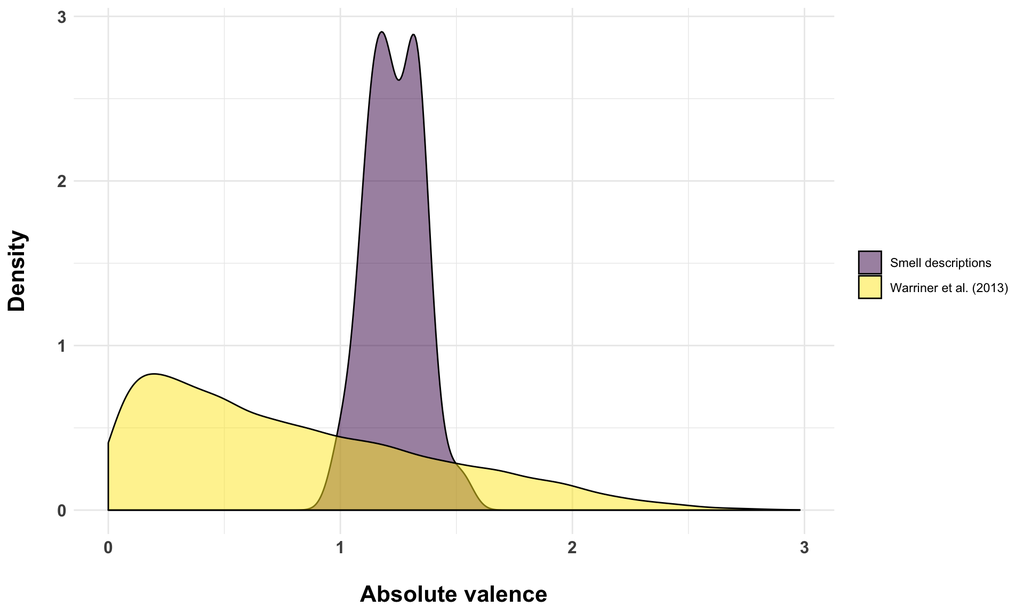

```r
absval %>% ggplot(aes(x = AbsVal, fill = Type)) +
  geom_density(alpha = 0.5) + scale_fill_viridis_d() +
  theme_minimal() +
  xlab('Absolute valence') +
  ylab('Density') +
  theme_minimal() +
  theme(axis.text.x = element_text(face = 'bold', size = 12),
        axis.text.y = element_text(face = 'bold', size = 12),
        axis.title.x = element_text(face = 'bold', size = 16,
                                    margin = margin(t = 20, r = 0, b = 0, l = 0)),
        axis.title.y = element_text(face = 'bold', size = 16,
                                    margin = margin(t = 0, r = 20, b = 0, l = 0)),
        plot.title = element_text(face = 'bold', size = 22),
        legend.title = element_blank())
```

```r
ggsave('../figures/absolute_valence.pdf', width = 9, height = 6)
```

Put both together for comparison, modality exclusivity:

```r
# Extract valence only:

excl_only <- select(scents, Excl_nochem)
excl_only$Type <- 'Smell descriptions'
excl_only <- excl_only %>% rename(Excl = Excl_nochem)

# Extract valence from warriner data frame:

excl_baseline <- lyn %>%
  filter(!(DominantModality %in% chem)) %>%
  rename(Excl = ModalityExclusivity) %>%
  select(Excl)
excl_baseline$Type <- 'Lynott & Connell (2009)'

# Merge:

excl <- bind_rows(excl_only, excl_baseline)
```

Make a plot of this:

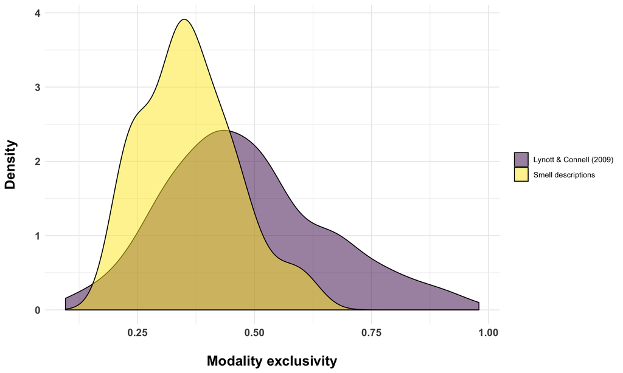

```r
excl %>% ggplot(aes(x = Excl, fill = Type)) +
  geom_density(alpha = 0.5) +
  scale_fill_viridis_d() +
  xlab('Modality exclusivity') +
  ylab('Density') +
  theme_minimal() +
  theme(axis.text.x = element_text(face = 'bold', size = 12),
        axis.text.y = element_text(face = 'bold', size = 12),
        axis.title.x = element_text(face = 'bold', size = 16,
                                    margin = margin(t = 20, r = 0, b = 0, l = 0)),
        axis.title.y = element_text(face = 'bold', size = 16,
                                    margin = margin(t = 0, r = 20, b = 0, l = 0)),
        plot.title = element_text(face = 'bold', size = 22),
        legend.title = element_blank())
```

```r
ggsave('../figures/exclusivity_valence.pdf', width = 9, height = 6)
```